# Exercise 4: Analysis

*In this week’s exercise, we use the linear discriminant analysis to predict an outcome (crime rate category) based on several predictor variables. We test the predictive power of the model with a test set (subset of the original data). This analysis helps in determining which variables discriminate the outcome categories best. Finally we use the clustering approach to try and determine the “best” number of clusters in the dataset.*

## TASK 2

## Loading the Boston data from the MASS package and checking the structure and the dimensions of the data

```r
library(MASS) #accessing the MASS package
data("Boston") #loading the data
str(Boston) #structure
```

```
## 'data.frame':    506 obs. of  14 variables:
##  $ crim   : num  0.00632 0.02731 0.02729 0.03237 0.06905 ...
##  $ zn     : num  18 0 0 0 0 0 12.5 12.5 12.5 12.5 ...
##  $ indus  : num  2.31 7.07 7.07 2.18 2.18 2.18 7.87 7.87 7.87 7.87 ...
##  $ chas   : int  0 0 0 0 0 0 0 0 0 0 ...
##  $ nox    : num  0.538 0.469 0.469 0.458 0.458 0.458 0.524 0.524 0.524 0.524 ...
##  $ rm     : num  6.58 6.42 7.18 7 7.15 ...
##  $ age    : num  65.2 78.9 61.1 45.8 54.2 58.7 66.6 96.1 100 85.9 ...
##  $ dis    : num  4.09 4.97 4.97 6.06 6.06 ...
##  $ rad    : int  1 2 2 3 3 3 5 5 5 5 ...
##  $ tax    : num  296 242 242 222 222 222 311 311 311 311 ...
##  $ ptratio: num  15.3 17.8 17.8 18.7 18.7 18.7 15.2 15.2 15.2 15.2 ...
##  $ black  : num  397 397 393 395 397 ...
##  $ lstat  : num  4.98 9.14 4.03 2.94 5.33 ...
##  $ medv   : num  24 21.6 34.7 33.4 36.2 28.7 22.9 27.1 16.5 18.9 ...
```

```r
dim(Boston) #dimensions
```

```
## [1] 506  14
```

*The data frame has 506 observations and 14 variables. The data have been collected in suburbs in Boston, and they include different housing values related variables, such as per capita crime rate, average number of rooms per dwelling etc., for each suburb studied. The variable descriptions can be found here: https://stat.ethz.ch/R-manual/R-devel/library/MASS/html/Boston.html.*

## TASK 3

## Graphical overview of the data, summaries of the variables

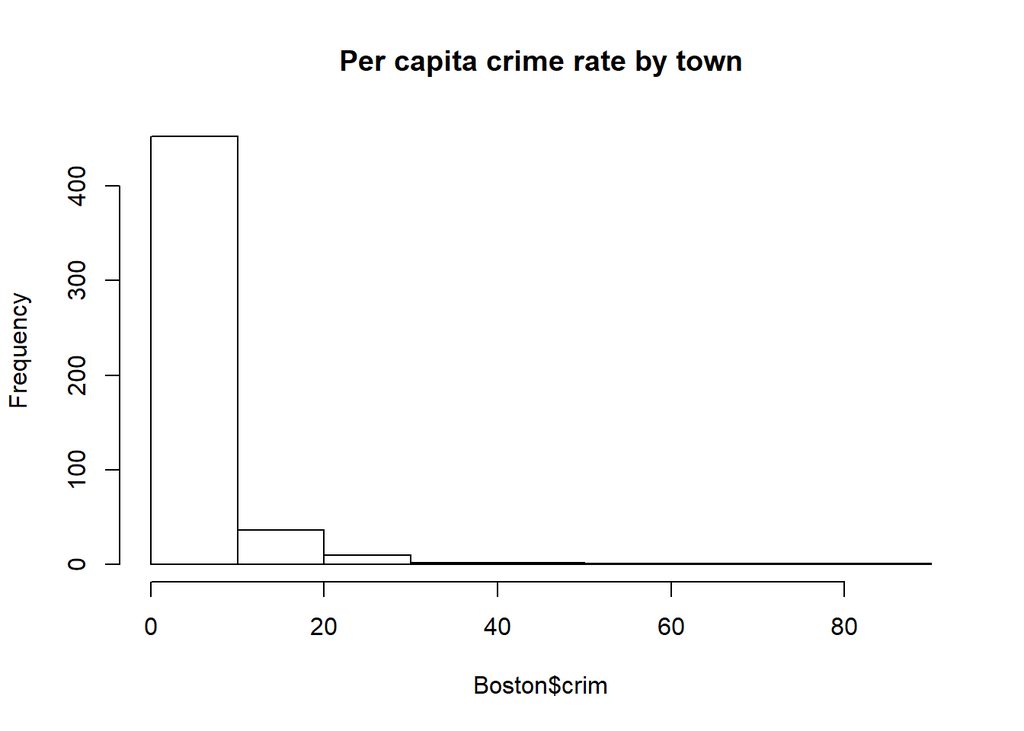

```r
library("GGally") #access to the GGally library and the ggpairs() function
#Histograms of the continuous variables:
hist(Boston$crim,main="Per capita crime rate by town")
```

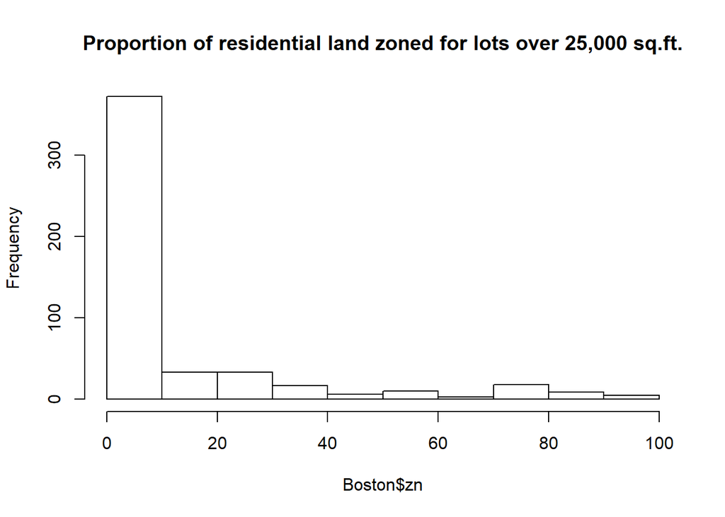

```r
hist(Boston$zn,main="Proportion of residential land zoned for lots over 25,000 sq.ft.")
```

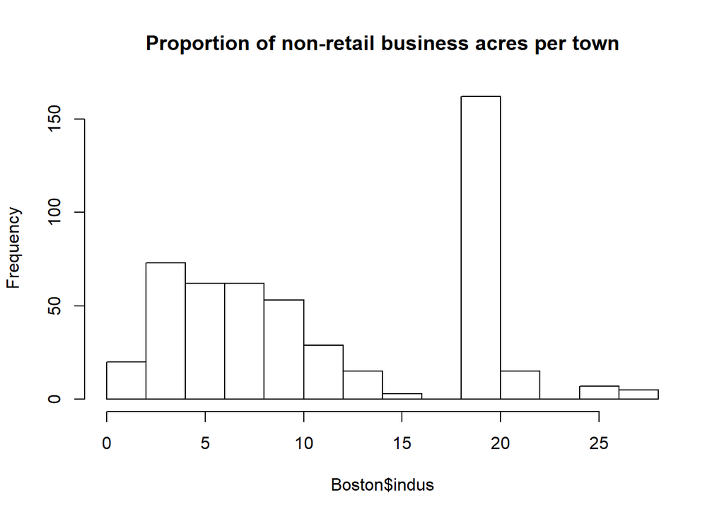

```r
hist(Boston$indus,main="Proportion of non-retail business acres per town")
```

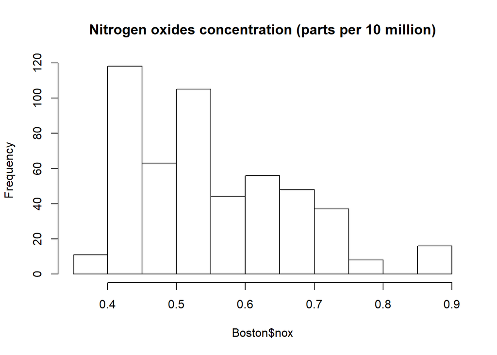

```r
hist(Boston$nox,main="Nitrogen oxides concentration (parts per 10 million)")
```

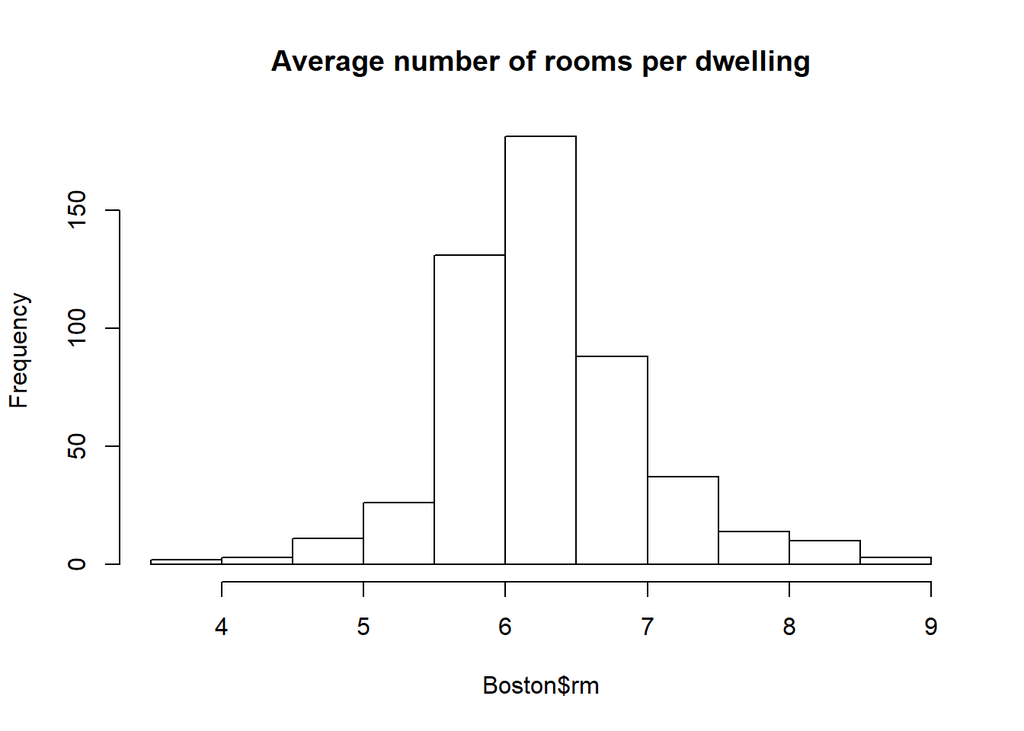

```r
hist(Boston$rm,main="Average number of rooms per dwelling")
```

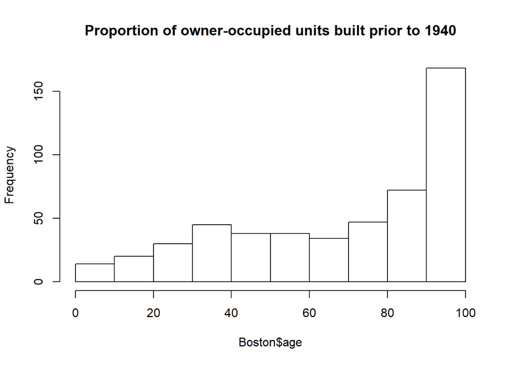

```r
hist(Boston$age,main="Proportion of owner-occupied units built prior to 1940")
```

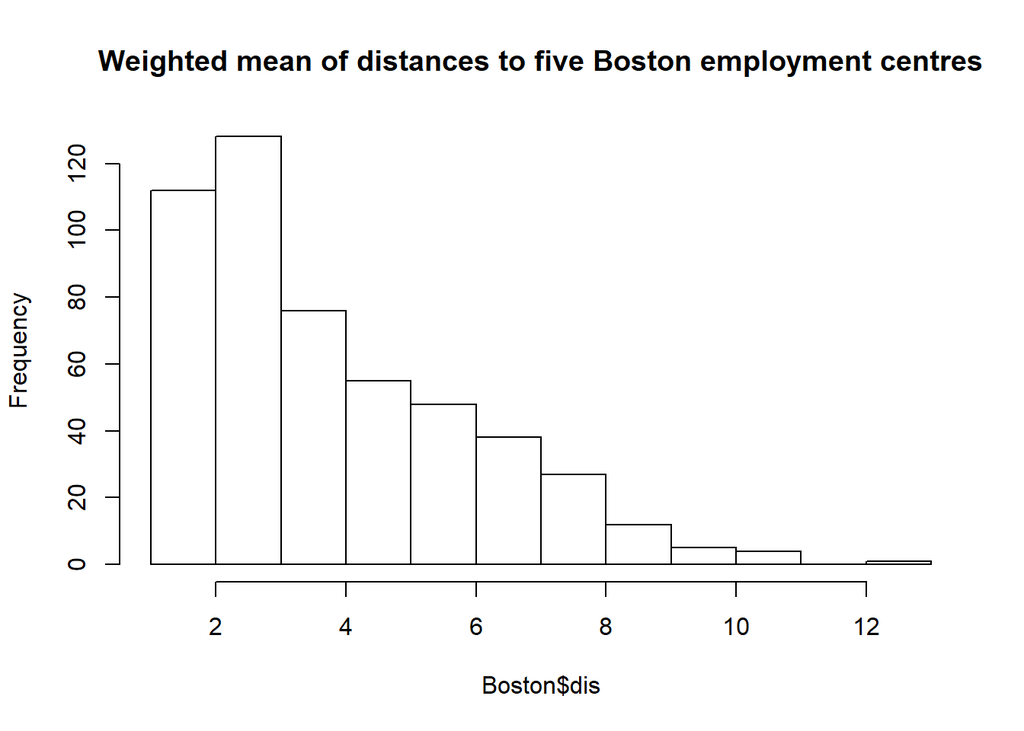

```r
hist(Boston$dis,main="Weighted mean of distances to five Boston employment centres")
```

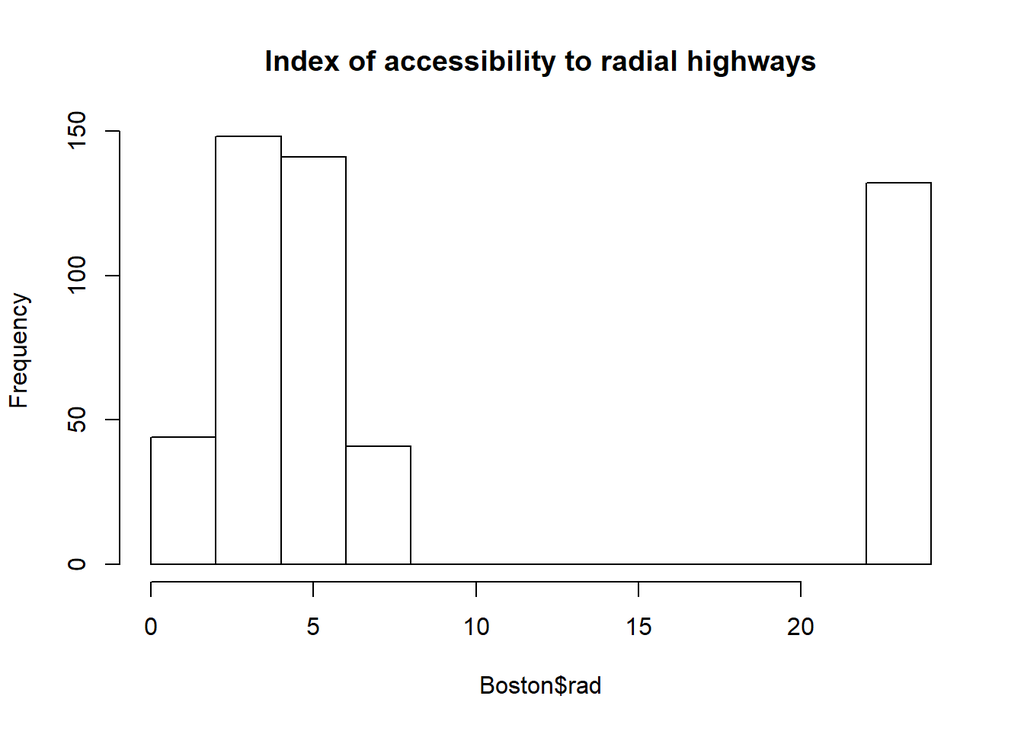

```r
hist(Boston$rad,main="Index of accessibility to radial highways")
```

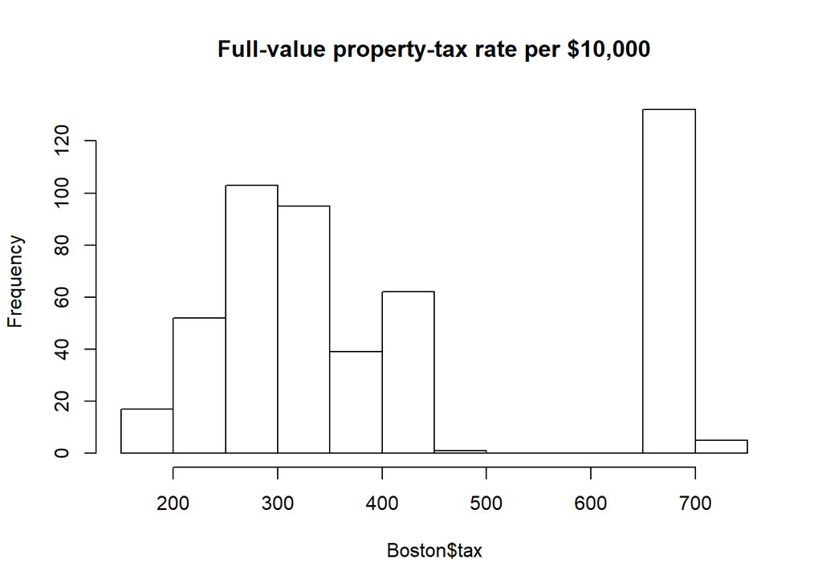

```r
hist(Boston$tax,main="Full-value property-tax rate per $10,000")
```

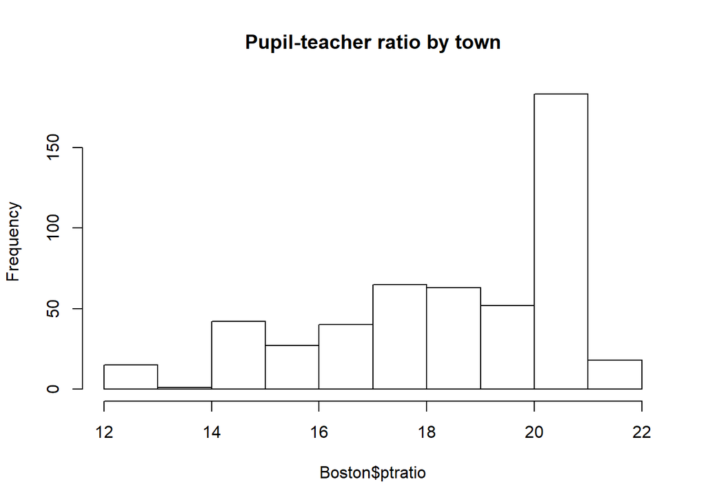

```r
hist(Boston$ptratio,main="Pupil-teacher ratio by town")
```

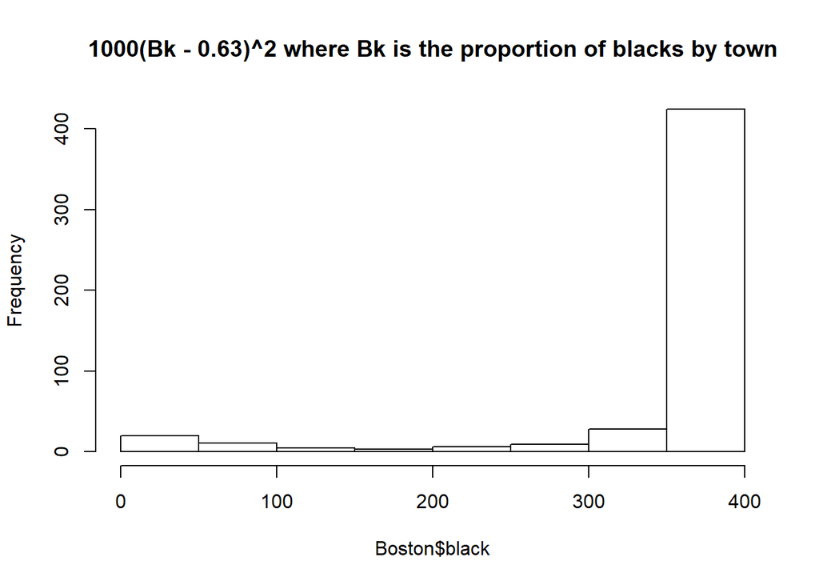

```r
hist(Boston$black,main="1000(Bk - 0.63)^2 where Bk is the proportion of blacks by town")
```

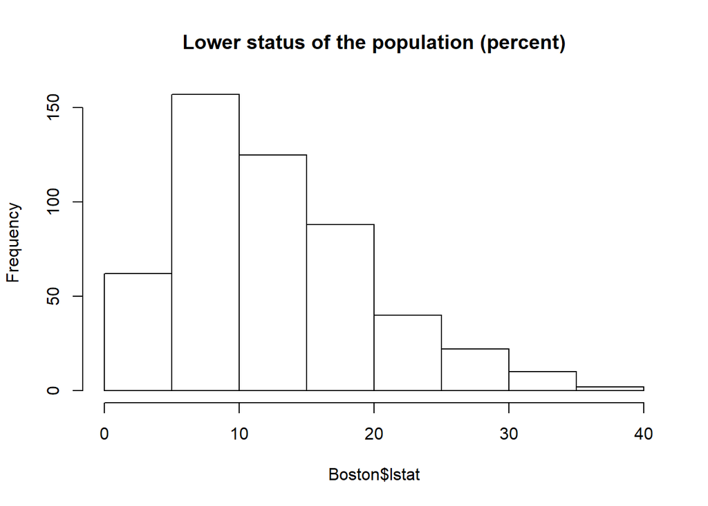

```r
hist(Boston$lstat,main="Lower status of the population (percent)")
```

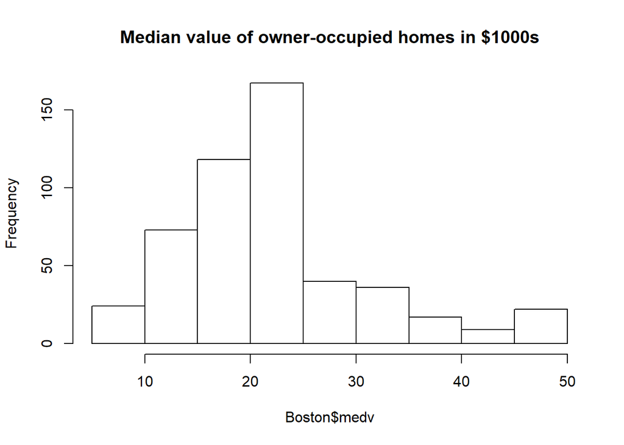

```r
hist(Boston$medv,main="Median value of owner-occupied homes in $1000s")
```

```r
#Summaries of the variables:
summary(Boston)
```

```
##       crim                zn             indus            chas
##  Min.   : 0.00632   Min.   :  0.00   Min.   : 0.46   Min.   :0.00000
##  1st Qu.: 0.08204   1st Qu.:  0.00   1st Qu.: 5.19   1st Qu.:0.00000
##  Median : 0.25651   Median :  0.00   Median : 9.69   Median :0.00000
##  Mean   : 3.61352   Mean   : 11.36   Mean   :11.14   Mean   :0.06917
##  3rd Qu.: 3.67708   3rd Qu.: 12.50   3rd Qu.:18.10   3rd Qu.:0.00000
##  Max.   :88.97620   Max.   :100.00   Max.   :27.74   Max.   :1.00000
##       nox               rm             age              dis
##  Min.   :0.3850   Min.   :3.561   Min.   :  2.90   Min.   : 1.130
##  1st Qu.:0.4490   1st Qu.:5.886   1st Qu.: 45.02   1st Qu.: 2.100
##  Median :0.5380   Median :6.208   Median : 77.50   Median : 3.207
##  Mean   :0.5547   Mean   :6.285   Mean   : 68.57   Mean   : 3.795
##  3rd Qu.:0.6240   3rd Qu.:6.623   3rd Qu.: 94.08   3rd Qu.: 5.188
##  Max.   :0.8710   Max.   :8.780   Max.   :100.00   Max.   :12.127
##       rad              tax           ptratio          black
##  Min.   : 1.000   Min.   :187.0   Min.   :12.60   Min.   :  0.32
##  1st Qu.: 4.000   1st Qu.:279.0   1st Qu.:17.40   1st Qu.:375.38
##  Median : 5.000   Median :330.0   Median :19.05   Median :391.44
##  Mean   : 9.549   Mean   :408.2   Mean   :18.46   Mean   :356.67
##  3rd Qu.:24.000   3rd Qu.:666.0   3rd Qu.:20.20   3rd Qu.:396.23
##  Max.   :24.000   Max.   :711.0   Max.   :22.00   Max.   :396.90
##      lstat            medv
##  Min.   : 1.73   Min.   : 5.00
##  1st Qu.: 6.95   1st Qu.:17.02
##  Median :11.36   Median :21.20
##  Mean   :12.65   Mean   :22.53
##  3rd Qu.:16.95   3rd Qu.:25.00
##  Max.   :37.97   Max.   :50.00
```

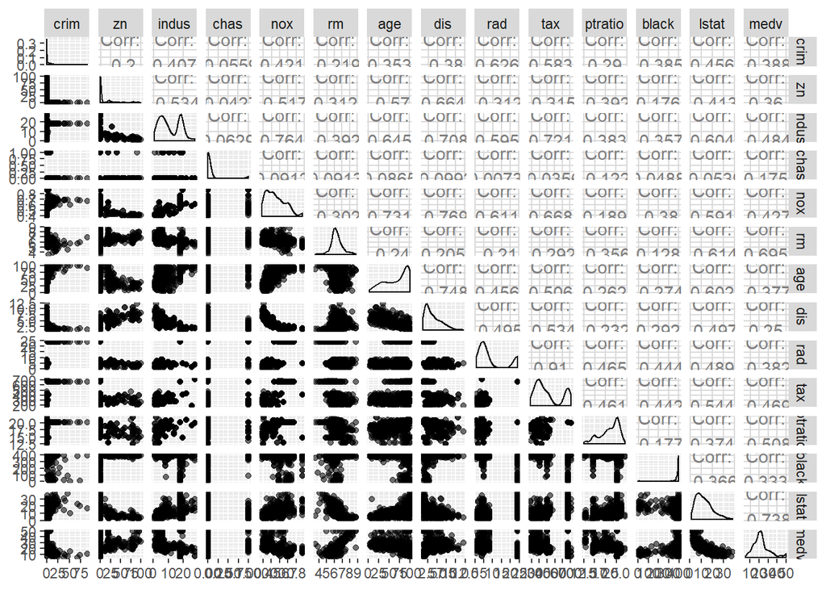

```r
#Correlations between the variables:
matrix <- ggpairs(Boston, mapping = aes(alpha = 0.3), lower = list(combo = wrap("facethist", bins = 20)))
matrix
```

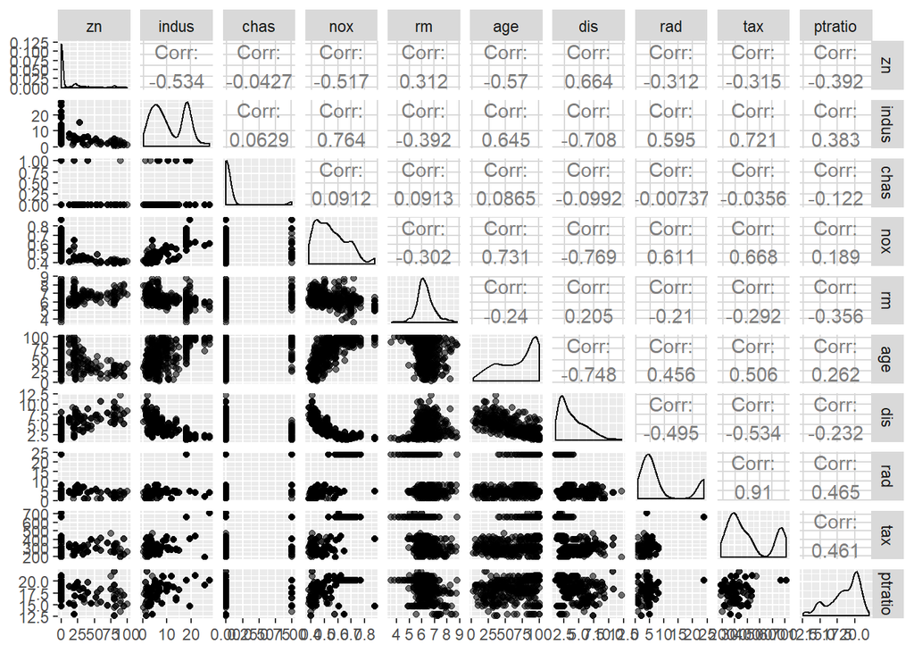

```r
#Inspecting more closely the relationships between specific promising variables (vars showing good correlation with other vars):
promise <- c(Boston$zn, Boston$indus, Boston$nox, Boston$rm, Boston$ptratio, Boston$lstat)
matrix2 <- ggpairs(Boston, columns=2:11, mapping = aes(alpha = 0.3), lower = list(combo = wrap("facethist", bins = 20)))
matrix2
```

Overall, we can see that many variables in this dataset are skewed in distribution. The outputs show us e.g. that in most areas, per capita crime rate is very low (Md=0.26, range 0.01-88.98), as is the proportion of residential land zoned for lots over 25,000 square feet (Md=0.00, range0.00-100.00) (i.e. in almost all areas, families tend to live within smaller lots than around 2,300 square meters). Many areas have around 20% proportion of non-retail business acres (range 0.46-27.74%). In half of the areas studied, nitrogen oxides concentration is lower than 0.54 parts per 10 million (range 0.39-0.87). I most areas, the average number of rooms per dwelling is around six (range 3.56-8.78). The most common pupil-teacher ratio is around 20 (20 pupils per teacher), ranging from 12.60 to 22.00.

Strong correlations can also be seen between the variables indus and tax (the greater the proportion of non-retail industry acres, the greater the full-value property-tax rate, r=0.721) and indus and dis (the greater the proportion of non-retail industry acres, the smaller the distances to employment centers, r=-0.708).

In short, the air quality seems to be worst nearest to the employment centers, old buildings and non-retail industry; and non-retail industry tend to be located near the employment centers and have higher property taxes.

## TASK 4

## Standardizing the dataset, creating a new categorical var and dividing the dataset

In order to conduct the linear discriminant analysis, we need to scale the data first. This is because of the underlying assumptions that each variable has the same variance and that variables are normally distributed. We also need to have a categorical variable as the outcome variable, so we need to categorize the continuous variable “crim”.

```r
#Positioning each variable so on the x axis that the mean is 0 -> saving to an object:
Boston_scaled <- scale(Boston)

#Summaries of the scaled vars:
summary(Boston_scaled)
```

```
##       crim                 zn               indus
##  Min.   :-0.419367   Min.   :-0.48724   Min.   :-1.5563
##  1st Qu.:-0.410563   1st Qu.:-0.48724   1st Qu.:-0.8668
##  Median :-0.390280   Median :-0.48724   Median :-0.2109
##  Mean   : 0.000000   Mean   : 0.00000   Mean   : 0.0000
##  3rd Qu.: 0.007389   3rd Qu.: 0.04872   3rd Qu.: 1.0150
##  Max.   : 9.924110   Max.   : 3.80047   Max.   : 2.4202
##       chas              nox                rm               age
##  Min.   :-0.2723   Min.   :-1.4644   Min.   :-3.8764   Min.   :-2.3331
##  1st Qu.:-0.2723   1st Qu.:-0.9121   1st Qu.:-0.5681   1st Qu.:-0.8366
##  Median :-0.2723   Median :-0.1441   Median :-0.1084   Median : 0.3171
##  Mean   : 0.0000   Mean   : 0.0000   Mean   : 0.0000   Mean   : 0.0000
##  3rd Qu.:-0.2723   3rd Qu.: 0.5981   3rd Qu.: 0.4823   3rd Qu.: 0.9059
##  Max.   : 3.6648   Max.   : 2.7296   Max.   : 3.5515   Max.   : 1.1164
##       dis               rad               tax             ptratio
##  Min.   :-1.2658   Min.   :-0.9819   Min.   :-1.3127   Min.   :-2.7047
##  1st Qu.:-0.8049   1st Qu.:-0.6373   1st Qu.:-0.7668   1st Qu.:-0.4876
##  Median :-0.2790   Median :-0.5225   Median :-0.4642   Median : 0.2746
##  Mean   : 0.0000   Mean   : 0.0000   Mean   : 0.0000   Mean   : 0.0000
##  3rd Qu.: 0.6617   3rd Qu.: 1.6596   3rd Qu.: 1.5294   3rd Qu.: 0.8058
##  Max.   : 3.9566   Max.   : 1.6596   Max.   : 1.7964   Max.   : 1.6372
##      black             lstat              medv
##  Min.   :-3.9033   Min.   :-1.5296   Min.   :-1.9063
##  1st Qu.: 0.2049   1st Qu.:-0.7986   1st Qu.:-0.5989
##  Median : 0.3808   Median :-0.1811   Median :-0.1449
##  Mean   : 0.0000   Mean   : 0.0000   Mean   : 0.0000
##  3rd Qu.: 0.4332   3rd Qu.: 0.6024   3rd Qu.: 0.2683
##  Max.   : 0.4406   Max.   : 3.5453   Max.   : 2.9865
```

```r
#Changing the object to a data frame:
Boston_scaled <- as.data.frame(Boston_scaled)
```

We can see that while the mean of every variable is 0.00, distribution of many variables still varies from normal - this may be problematic for the assumptions of the linear discriminant analysis.

```r
#Creating a categorical variable of the crime rate using the quantiles as the break points:
quantile_vector <- quantile(Boston_scaled$crim) #creating a vector for the quantiles
quantile_vector #checking the break points
```

```
##           0%          25%          50%          75%         100%
## -0.419366929 -0.410563278 -0.390280295  0.007389247  9.924109610
```

```r
crime_categ <- cut(Boston_scaled$crim, breaks = quantile_vector, include.lowest = TRUE) #Creating the new var with 4 levels

#Dropping the old continuous crime rate var ("crim") from the dataset and adding the new categorical one ("crime_categ"):
Boston_scaled <- dplyr::select(Boston_scaled, -crim)
Boston_scaled <- data.frame(Boston_scaled, crime_categ)
summary(Boston_scaled)
```

```
##        zn               indus              chas              nox
##  Min.   :-0.48724   Min.   :-1.5563   Min.   :-0.2723   Min.   :-1.4644
##  1st Qu.:-0.48724   1st Qu.:-0.8668   1st Qu.:-0.2723   1st Qu.:-0.9121
##  Median :-0.48724   Median :-0.2109   Median :-0.2723   Median :-0.1441
##  Mean   : 0.00000   Mean   : 0.0000   Mean   : 0.0000   Mean   : 0.0000
##  3rd Qu.: 0.04872   3rd Qu.: 1.0150   3rd Qu.:-0.2723   3rd Qu.: 0.5981
##  Max.   : 3.80047   Max.   : 2.4202   Max.   : 3.6648   Max.   : 2.7296
##        rm               age               dis               rad
##  Min.   :-3.8764   Min.   :-2.3331   Min.   :-1.2658   Min.   :-0.9819
##  1st Qu.:-0.5681   1st Qu.:-0.8366   1st Qu.:-0.8049   1st Qu.:-0.6373
##  Median :-0.1084   Median : 0.3171   Median :-0.2790   Median :-0.5225
##  Mean   : 0.0000   Mean   : 0.0000   Mean   : 0.0000   Mean   : 0.0000
##  3rd Qu.: 0.4823   3rd Qu.: 0.9059   3rd Qu.: 0.6617   3rd Qu.: 1.6596
##  Max.   : 3.5515   Max.   : 1.1164   Max.   : 3.9566   Max.   : 1.6596
##       tax             ptratio            black             lstat
##  Min.   :-1.3127   Min.   :-2.7047   Min.   :-3.9033   Min.   :-1.5296
##  1st Qu.:-0.7668   1st Qu.:-0.4876   1st Qu.: 0.2049   1st Qu.:-0.7986
##  Median :-0.4642   Median : 0.2746   Median : 0.3808   Median :-0.1811
##  Mean   : 0.0000   Mean   : 0.0000   Mean   : 0.0000   Mean   : 0.0000
##  3rd Qu.: 1.5294   3rd Qu.: 0.8058   3rd Qu.: 0.4332   3rd Qu.: 0.6024
##  Max.   : 1.7964   Max.   : 1.6372   Max.   : 0.4406   Max.   : 3.5453
##       medv                  crime_categ
##  Min.   :-1.9063   [-0.419,-0.411]:127
##  1st Qu.:-0.5989   (-0.411,-0.39] :126
##  Median :-0.1449   (-0.39,0.00739]:126
##  Mean   : 0.0000   (0.00739,9.92] :127
##  3rd Qu.: 0.2683
##  Max.   : 2.9865
```

Now we can see that the new crime_categ variable has four levels, and each level has 126 or 127 cases.

We are about to create a model and train it using one subset of the data (80%) and to test the predictive power of the model using another subset (20%). Therefore, the dataset needs to be split in two.

```r
row_n <- nrow(Boston_scaled)  #saving the number of rows
chosen_rows <- sample(row_n, size = row_n * 0.8) #Choosing randomly 80% of the rows

#Dividing the data set to train and test sets:
train <- Boston_scaled[chosen_rows,]
test <- Boston_scaled[-chosen_rows,]
```

## TASK 5

## Fitting the linear discriminant analysis (LDA) on the train set and drawing the LDA biplot

We use the categorical crime rate variable as the target variable and all the other vars as predictor variables.

```r
library(dplyr)
lda.fit <- lda(crime_categ ~ ., data = train) #Using the train set for the analysis
lda.fit
```

```
## Call:
## lda(crime_categ ~ ., data = train)
##
## Prior probabilities of groups:
## [-0.419,-0.411]  (-0.411,-0.39] (-0.39,0.00739]  (0.00739,9.92]
##       0.2351485       0.2574257       0.2549505       0.2524752
##
## Group means:
##                         zn      indus        chas        nox         rm
## [-0.419,-0.411]  0.9532059 -0.9065116 -0.06511327 -0.8542793  0.4247088
## (-0.411,-0.39]  -0.1217538 -0.2667431  0.03052480 -0.5476918 -0.1813409
## (-0.39,0.00739] -0.3856672  0.1599054  0.22458650  0.3479070  0.0837045
## (0.00739,9.92]  -0.4872402  1.0171096 -0.04073494  1.0841473 -0.3397620
##                        age        dis        rad        tax    ptratio
## [-0.419,-0.411] -0.8397893  0.8986319 -0.6905232 -0.7731878 -0.4447696
## (-0.411,-0.39]  -0.2991615  0.2990215 -0.5556132 -0.4558836 -0.0762832
## (-0.39,0.00739]  0.3891189 -0.3482620 -0.3786473 -0.2962919 -0.2314907
## (0.00739,9.92]   0.8365051 -0.8557458  1.6382099  1.5141140  0.7808718
##                      black       lstat        medv
## [-0.419,-0.411]  0.3829324 -0.76671633  0.50219858
## (-0.411,-0.39]   0.3165199 -0.07545551 -0.03566325
## (-0.39,0.00739]  0.1286267  0.02857056  0.16406700
## (0.00739,9.92]  -0.8089583  0.86934067 -0.66063660
##
## Coefficients of linear discriminants:
##                  LD1         LD2         LD3
## zn       0.057462173  0.91110820 -0.82213130
## indus   -0.006261928 -0.20050277  0.12767644
## chas    -0.070182321 -0.05594543  0.08807235
## nox      0.440172469 -0.58051709 -1.55624105
## rm      -0.072199268 -0.07537304 -0.18792591
## age      0.263219516 -0.24929022 -0.22414508
## dis     -0.027566779 -0.23965368 -0.08398342
## rad      3.012389224  0.94722291 -0.15354566
## tax     -0.027423835 -0.13028640  0.89817068
## ptratio  0.115730555  0.04702098 -0.34907561
## black   -0.133948342 -0.01017829  0.10163815
## lstat    0.194110847 -0.24489303  0.37198021
## medv     0.177926811 -0.38885684 -0.25673077
##
## Proportion of trace:
##    LD1    LD2    LD3
## 0.9453 0.0386 0.0161
```

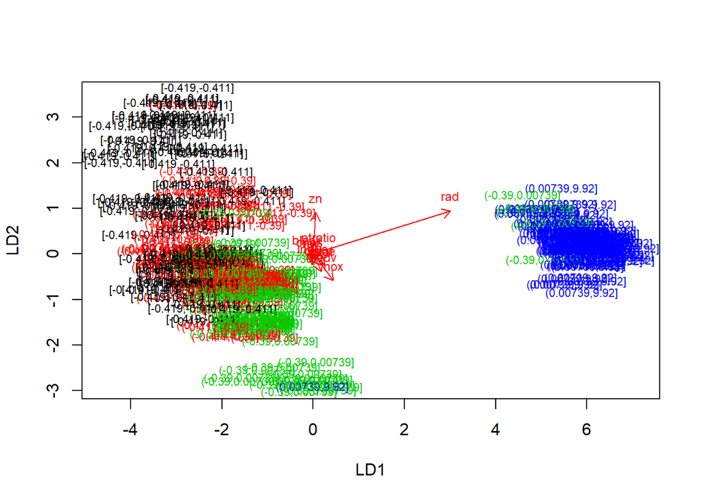

```r
#The function for lda biplot arrows:
lda.arrows <- function(x, myscale = 1, arrow_heads = 0.1, color = "red", tex = 0.75, choices = c(1,2)){
  heads <- coef(x)
  arrows(x0 = 0, y0 = 0,
         x1 = myscale * heads[,choices[1]],
         y1 = myscale * heads[,choices[2]], col=color, length = arrow_heads)
  text(myscale * heads[,choices], labels = row.names(heads),
       cex = tex, col=color, pos=3)
}

classes <- as.numeric(train$crime_categ)  #targeting classes as numeric

plot(lda.fit, dimen = 2, col = classes, pch = classes)
lda.arrows(lda.fit, myscale =1)
```

It seems that the category with highest crime rate (blue) is clearly separate from the other three categories. The categories with lowest (black) and second highest crime rate (green) are also rather well distinguishable.

## TASK 6

## Saving + removing the crime categories from the test set and predicting the outcomes in the test data

```r
#Saving the crime categories from the test subset as correct classes and then removing these categories from the test data:
correct_categ <- test$crime_categ
correct_categ #checking the saved categories
```

```
##   [1] [-0.419,-0.411] (-0.39,0.00739] (-0.39,0.00739] (-0.39,0.00739]
##   [5] (-0.39,0.00739] (-0.411,-0.39]  (-0.411,-0.39]  (-0.411,-0.39]
##   [9] (-0.411,-0.39]  [-0.419,-0.411] [-0.419,-0.411] [-0.419,-0.411]
##  [13] (-0.411,-0.39]  [-0.419,-0.411] (-0.411,-0.39]  [-0.419,-0.411]
##  [17] [-0.419,-0.411] [-0.419,-0.411] [-0.419,-0.411] [-0.419,-0.411]
##  [21] (-0.411,-0.39]  (-0.411,-0.39]  (-0.411,-0.39]  (-0.39,0.00739]
##  [25] (-0.39,0.00739] (-0.39,0.00739] (-0.39,0.00739] (-0.39,0.00739]
##  [29] (-0.39,0.00739] (-0.39,0.00739] (-0.39,0.00739] (-0.39,0.00739]
##  [33] (-0.39,0.00739] [-0.419,-0.411] [-0.419,-0.411] [-0.419,-0.411]
##  [37] (-0.411,-0.39]  [-0.419,-0.411] [-0.419,-0.411] (-0.411,-0.39]
##  [41] (-0.411,-0.39]  [-0.419,-0.411] [-0.419,-0.411] [-0.419,-0.411]
##  [45] (-0.411,-0.39]  (-0.411,-0.39]  (-0.39,0.00739] (-0.411,-0.39]
##  [49] (-0.411,-0.39]  (-0.411,-0.39]  (-0.411,-0.39]  [-0.419,-0.411]
##  [53] [-0.419,-0.411] (-0.39,0.00739] (-0.39,0.00739] (-0.39,0.00739]
##  [57] [-0.419,-0.411] [-0.419,-0.411] [-0.419,-0.411] [-0.419,-0.411]
##  [61] [-0.419,-0.411] [-0.419,-0.411] (-0.39,0.00739] (-0.39,0.00739]
##  [65] (-0.39,0.00739] (-0.411,-0.39]  (-0.411,-0.39]  (-0.39,0.00739]
##  [69] (-0.411,-0.39]  [-0.419,-0.411] [-0.419,-0.411] [-0.419,-0.411]
##  [73] [-0.419,-0.411] [-0.419,-0.411] (0.00739,9.92]  (0.00739,9.92]
##  [77] (0.00739,9.92]  (0.00739,9.92]  (0.00739,9.92]  (0.00739,9.92]
##  [81] (0.00739,9.92]  (0.00739,9.92]  (0.00739,9.92]  (0.00739,9.92]
##  [85] (0.00739,9.92]  (0.00739,9.92]  (0.00739,9.92]  (0.00739,9.92]
##  [89] (0.00739,9.92]  (0.00739,9.92]  (0.00739,9.92]  (0.00739,9.92]
##  [93] (0.00739,9.92]  (0.00739,9.92]  (0.00739,9.92]  (0.00739,9.92]
##  [97] (0.00739,9.92]  (0.00739,9.92]  (0.00739,9.92]  (-0.39,0.00739]
## [101] [-0.419,-0.411] (-0.411,-0.39]
## 4 Levels: [-0.419,-0.411] (-0.411,-0.39] ... (0.00739,9.92]
```

```r
test <- dplyr::select(test, -crime_categ)

#Predicting the classes (crime categories) using the LDA model:
lda.pred <- predict(lda.fit, newdata = test)  #saving the predictions into a new object

table(correct = correct_categ, predicted = lda.pred$class)
```

```
##                  predicted
## correct           [-0.419,-0.411] (-0.411,-0.39] (-0.39,0.00739]
##   [-0.419,-0.411]              16             14               2
##   (-0.411,-0.39]                7             12               3
##   (-0.39,0.00739]               1              4              18
##   (0.00739,9.92]                0              0               0
##                  predicted
## correct           (0.00739,9.92]
##   [-0.419,-0.411]              0
##   (-0.411,-0.39]               0
##   (-0.39,0.00739]              0
##   (0.00739,9.92]              25
```

## TASK 7

## Using the clustering approach to the observations in the Boston dataset

```r
#Reloading and standardizing the Boston dataset
data("Boston") #loading the data, MASS package available

#Positioning each variable so on the x axis that the mean is 0 -> saving to an object:
Boston_scaled2 <- scale(Boston)

#Summaries of the scaled vars:
summary(Boston_scaled2)
```

```
##       crim                 zn               indus
##  Min.   :-0.419367   Min.   :-0.48724   Min.   :-1.5563
##  1st Qu.:-0.410563   1st Qu.:-0.48724   1st Qu.:-0.8668
##  Median :-0.390280   Median :-0.48724   Median :-0.2109
##  Mean   : 0.000000   Mean   : 0.00000   Mean   : 0.0000
##  3rd Qu.: 0.007389   3rd Qu.: 0.04872   3rd Qu.: 1.0150
##  Max.   : 9.924110   Max.   : 3.80047   Max.   : 2.4202
##       chas              nox                rm               age
##  Min.   :-0.2723   Min.   :-1.4644   Min.   :-3.8764   Min.   :-2.3331
##  1st Qu.:-0.2723   1st Qu.:-0.9121   1st Qu.:-0.5681   1st Qu.:-0.8366
##  Median :-0.2723   Median :-0.1441   Median :-0.1084   Median : 0.3171
##  Mean   : 0.0000   Mean   : 0.0000   Mean   : 0.0000   Mean   : 0.0000
##  3rd Qu.:-0.2723   3rd Qu.: 0.5981   3rd Qu.: 0.4823   3rd Qu.: 0.9059
##  Max.   : 3.6648   Max.   : 2.7296   Max.   : 3.5515   Max.   : 1.1164
##       dis               rad               tax             ptratio
##  Min.   :-1.2658   Min.   :-0.9819   Min.   :-1.3127   Min.   :-2.7047
##  1st Qu.:-0.8049   1st Qu.:-0.6373   1st Qu.:-0.7668   1st Qu.:-0.4876
##  Median :-0.2790   Median :-0.5225   Median :-0.4642   Median : 0.2746
##  Mean   : 0.0000   Mean   : 0.0000   Mean   : 0.0000   Mean   : 0.0000
##  3rd Qu.: 0.6617   3rd Qu.: 1.6596   3rd Qu.: 1.5294   3rd Qu.: 0.8058
##  Max.   : 3.9566   Max.   : 1.6596   Max.   : 1.7964   Max.   : 1.6372
##      black             lstat              medv
##  Min.   :-3.9033   Min.   :-1.5296   Min.   :-1.9063
##  1st Qu.: 0.2049   1st Qu.:-0.7986   1st Qu.:-0.5989
##  Median : 0.3808   Median :-0.1811   Median :-0.1449
##  Mean   : 0.0000   Mean   : 0.0000   Mean   : 0.0000
##  3rd Qu.: 0.4332   3rd Qu.: 0.6024   3rd Qu.: 0.2683
##  Max.   : 0.4406   Max.   : 3.5453   Max.   : 2.9865
```

```r
#Changing the object to a data frame:
Boston_scaled2 <- as.data.frame(Boston_scaled2)

#Calculating the distances (similarity/dissimilarity) between observations)
dist_eu <- dist(Boston_scaled2)  #euclidean distance matrix calculates the usual distance between two vectors
dist_man <- dist(Boston_scaled2, method = "manhattan")  #manhattan distance matrix calculates the absolute distance between two vectors

summary(dist_man)
```

```
##    Min. 1st Qu.  Median    Mean 3rd Qu.    Max.
##  0.2662  8.4832 12.6090 13.5488 17.7568 48.8618
```

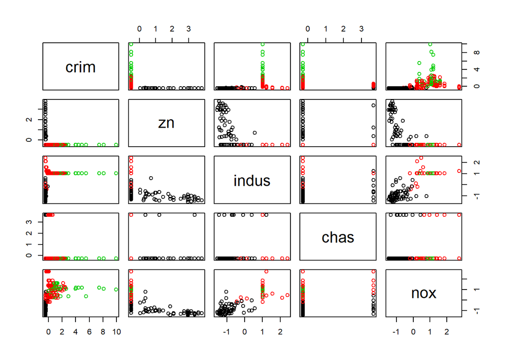

```r
#Running k-means algorithm as a clustering method

km <-kmeans(Boston_scaled2, centers = 3) #k-means clustering

pairs(Boston_scaled2[1:5], col = km$cluster) #plotting the Boston dataset with clusters
```

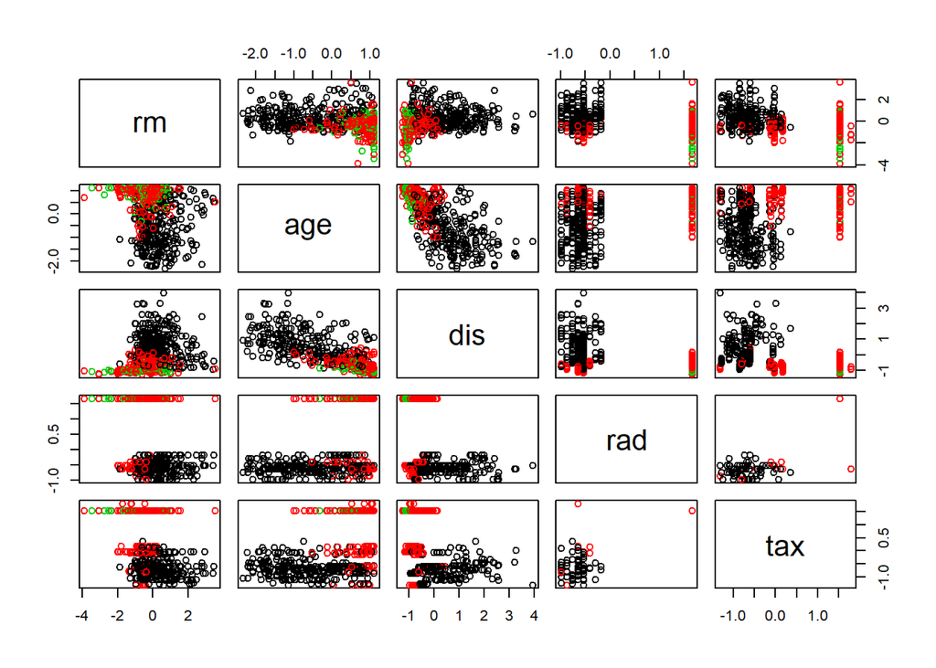

```r
pairs(Boston_scaled2[6:10], col = km$cluster)
```

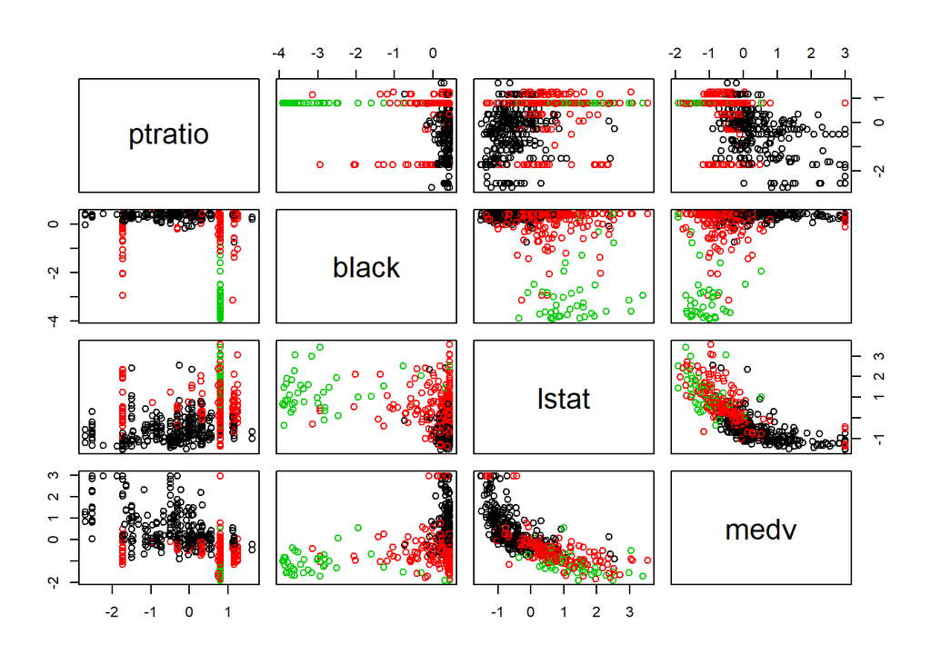

```r
pairs(Boston_scaled2[11:14], col = km$cluster)
```

The k-means clustering method assigns observations to clusters based on similarity of the objects. I ran the analysis with 3, 4, and 5 centers. Judged by the visualizations, the three-center solution seems to produce the most differing categories, and therefore I would try clustering the data into 3 groups. Based solely on the visualizations, among the most promising-looking variables for maximizing the distance between clusters are per capita crime rate (crim), proportion of non-retail business acres in town (indus), air pollution (nox), proportion of owner-occupied old units (age) and distances to employment centers (dis). These results are rather well in line with the initial correlation results shown below Task 3.